# Analyze 5 TCGA datasets using RAVmodel

Sehyun Oh

2021-02-21

# 1 Setup

## 1.1 Load packages

```r
suppressPackageStartupMessages({
  library(GenomicSuperSignature)
  library(dplyr)
  library(ggplot2)
})
```

## 1.2 TCGA datasets

`TCGA_validationDatasets` is a list containing 6 TCGA datasets: COAD, BRCA, LUAD, READ, UCEC, and OV. First 5 are raw read counts from `GSEABenchmarkeR` package with log2(count + 1) transformation. Also, `GSEABenchmarkeR::loadEData` excluded genes with cpm < 2 in more than half of the samples. TCGA-OV dataset is from `curatedOvarianData` package. This training dataset file was build using `R/build_TCGA_validationDatasets.R` script.

```r
load("data/TCGA_validationDatasets.rda")
names(TCGA_validationDatasets)
```

```
## [1] "COAD" "BRCA" "LUAD" "READ" "UCEC" "OV"
```

```r
# not using OV for this vigenette
datasets <- TCGA_validationDatasets[1:5]
```

## 1.3 RAVmodel

This RAVmodel is built using top 20 PCs of 536 studies. The number of cluster was decided by `d=2.25` and MSigDB C2 gene sets are used for GSEA-based annotation.

```r
data.dir <- system.file("extdata", package = "GenomicSuperSignaturePaper")
RAVmodel <- readRDS(file.path(data.dir, "RAVmodel_C2.rds"))
RAVmodel
## class: PCAGenomicSignatures
## dim: 13934 4764
## metadata(7): cluster size ... updateNote version
## assays(1): RAVindex
## rownames(13934): CASKIN1 DDX3Y ... CTC-457E21.9 AC007966.1
## rowData names(0):
## colnames(4764): RAV1 RAV2 ... RAV4763 RAV4764
## colData names(4): RAV studies silhouetteWidth gsea
## trainingData(2): PCAsummary MeSH
## trainingData names(536): DRP000987 SRP059172 ... SRP164913 SRP188526
updateNote(RAVmodel)
```

```
## [1] "536 refine.bio studies/ top 90% varying genes/ GSEA with MSigDB C2"
```

# 2 Multi-comparison (only TCGA)

## 2.1 heatmapTable (all)

Here, we plot the heatmapTable of validation result from multiple studies. By matching this result with metadata, you can identify RAVs that are more strongly associated with specific features.

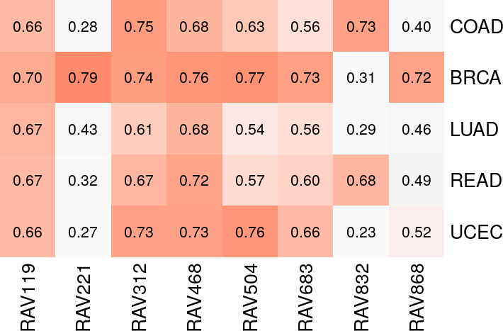

```r
# This process takes little time due to the size of datasets.
val_all <- validate(datasets, RAVmodel)
heatmapTable(val_all)
```

It seems like RAV221 and RAV868 are specific to BRCA while RAV832 is strongly associated with colon/rectal cancers.

## 2.2 heatmapTable (one dataset)

If you provide validation result from one dataset, `heatmapTable` include the average silhouette width as a reference.

### 2.2.1 COAD

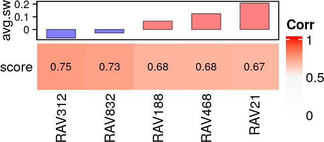

```r
val_coad <- validate(datasets[["COAD"]], RAVmodel)
heatmapTable(val_coad)
```

### 2.2.2 READ

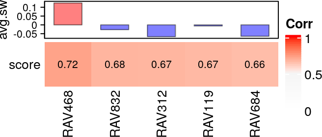

```r
val_read <- validate(datasets[["READ"]], RAVmodel)
heatmapTable(val_read)
```

### 2.2.3 BRCA

RAV221 shows the highest validation score with a positive avgerage silhouette width.

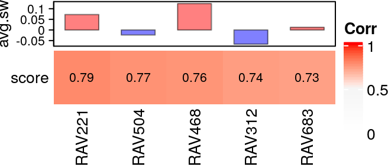

```r
val_brca <- validate(datasets[["BRCA"]], RAVmodel)
heatmapTable(val_brca)
```

RAV868 didn’t score top 5, so we checked a couple more top validated RAVs. RAV868 is ranked 6th based on the score with negative average silhouette width.

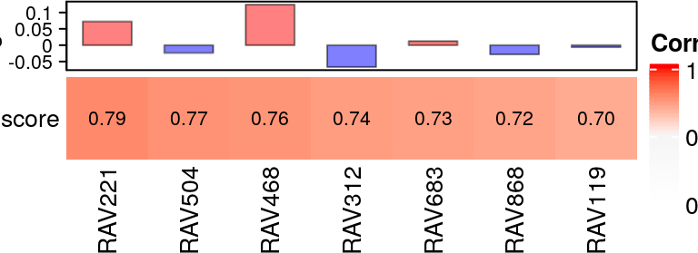

```r
heatmapTable(val_brca, num.out = 7)
```

## 2.3 MeSH terms and associated studies

### 2.3.1 BRCA-associated

RAV221 and RAV868 are specific to BRCA.

#### 2.3.1.1 RAV221

RAV221 consists of three breast cancer studies (ERP016798, SRP023262, and SRP11343) and top 10 enriched pathways are associated with breast cancer.

```r
ind <- 221
findStudiesInCluster(RAVmodel, ind, studyTitle = TRUE)
```

```
##      studyName
## 279  ERP016798
## 977  SRP023262
## 4275 SRP111343
##                                                                                                      title
## 279                                              Whole transcriptome profiling of 63 breast cancer tumours
## 977  A shared transcriptional program in early breast neoplasias despite genetic and clinical distinctions
## 4275                             RNAseq analysis of chemotherapy and radiation therapy-naïve breast tumors
```

```r
subsetEnrichedPathways(RAVmodel, ind) %>% as.data.frame
```

```
##                                                RAV221
## Up_1                      SMID_BREAST_CANCER_BASAL_DN
## Up_2                      DOANE_BREAST_CANCER_ESR1_UP
## Up_3                  SMID_BREAST_CANCER_LUMINAL_B_UP
## Up_4                   VANTVEER_BREAST_CANCER_ESR1_UP
## Up_5   LIEN_BREAST_CARCINOMA_METAPLASTIC_VS_DUCTAL_DN
## Up_6        CHARAFE_BREAST_CANCER_LUMINAL_VS_BASAL_UP
## Up_7  CHARAFE_BREAST_CANCER_LUMINAL_VS_MESENCHYMAL_UP
## Up_8            SMID_BREAST_CANCER_RELAPSE_IN_BONE_UP
## Up_9           SMID_BREAST_CANCER_RELAPSE_IN_BRAIN_DN
## Up_10                 POOLA_INVASIVE_BREAST_CANCER_DN
```

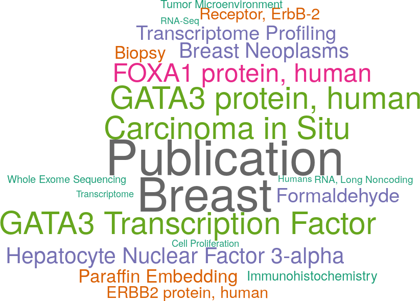

```r
drawWordcloud(RAVmodel, ind)
```

#### 2.3.1.2 RAV868

```r
ind <- 868
findStudiesInCluster(RAVmodel, ind, studyTitle = TRUE)
```

```
##      studyName
## 773  SRP014428
## 4275 SRP111343
## 5720 SRP158730
## 5843 SRP163173
## 5960 SRP169094
##                                                                                                    title
## 773           Full-length mRNA-Seq from single-cell levels of RNA and individual circulating tumor cells
## 4275                           RNAseq analysis of chemotherapy and radiation therapy-naïve breast tumors
## 5720                 Separation of breast cancer and organ microenvironment transcriptomes in metastases
## 5843                                Integrative epigenetic taxonomy of primary prostate cancer [RNA-Seq]
## 5960 On-Treatment Biomarkers Improve Prediction of Response to Neoadjuvant Chemotherapy in Breast Cancer
```

```r
subsetEnrichedPathways(RAVmodel, ind) %>% as.data.frame
```

```
##                                                RAV868
## Up_1  CHARAFE_BREAST_CANCER_LUMINAL_VS_MESENCHYMAL_UP
## Up_2   LIEN_BREAST_CARCINOMA_METAPLASTIC_VS_DUCTAL_DN
## Up_3                      DOANE_BREAST_CANCER_ESR1_UP
## Up_4        CHARAFE_BREAST_CANCER_LUMINAL_VS_BASAL_UP
## Up_5      ROSTY_CERVICAL_CANCER_PROLIFERATION_CLUSTER
## Up_6                         LIM_MAMMARY_STEM_CELL_DN
## Up_7                  COLDREN_GEFITINIB_RESISTANCE_DN
## Up_8                   DOANE_BREAST_CANCER_CLASSES_UP
## Up_9           SOTIRIOU_BREAST_CANCER_GRADE_1_VS_3_UP
## Up_10                  VANTVEER_BREAST_CANCER_ESR1_UP
```

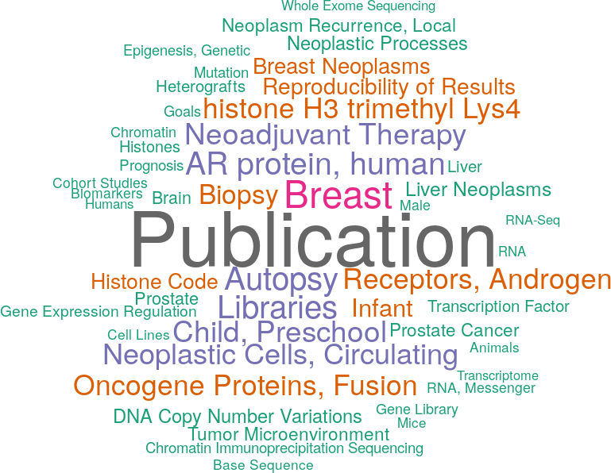

```r
drawWordcloud(RAVmodel, ind)
```

### 2.3.2 COAD/READ-associated

#### 2.3.2.1 RAV832

```r
ind <- 832
findStudiesInCluster(RAVmodel, ind, studyTitle = TRUE)
```

```
##      studyName
## 681  SRP010181
## 1074 SRP029880
## 2543 SRP068591
## 2792 SRP073267
## 4655 SRP123604
##                                                                          title
## 681                     Derivation of HLA types from shotgun sequence datasets
## 1074           Gene expression profiling study by RNA-seq in colorectal cancer
## 2543 Gene signature in sessile serrated polyps identifies colon cancer subtype
## 2792                  Impact of RNA degradation on fusion detection by RNA-seq
## 4655  Immune Profiling of Premalignant Lesions in Patients with Lynch Syndrome
```

```r
subsetEnrichedPathways(RAVmodel, ind) %>% as.data.frame
```

```
##                                                                     RAV832
## Up_1                                         SABATES_COLORECTAL_ADENOMA_UP
## Up_2                                            HSIAO_LIVER_SPECIFIC_GENES
## Up_3                                      GRADE_COLON_AND_RECTAL_CANCER_UP
## Up_4                            REACTOME_EUKARYOTIC_TRANSLATION_ELONGATION
## Up_5  REACTOME_SRP_DEPENDENT_COTRANSLATIONAL_PROTEIN_TARGETING_TO_MEMBRANE
## Up_6                                                         KEGG_RIBOSOME
## Up_7                                             LEE_LIVER_CANCER_ACOX1_DN
## Up_8                                  REACTOME_SELENOAMINO_ACID_METABOLISM
## Up_9                                      KOBAYASHI_EGFR_SIGNALING_24HR_DN
## Up_10                 REACTOME_REGULATION_OF_EXPRESSION_OF_SLITS_AND_ROBOS
```

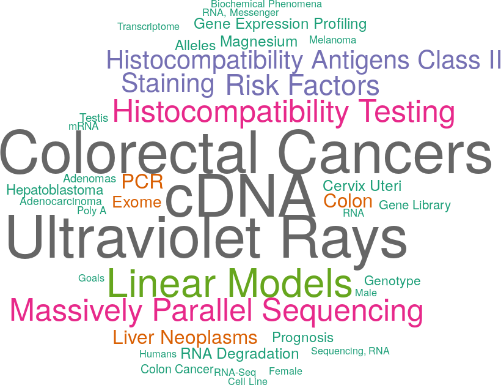

```r
drawWordcloud(RAVmodel, ind)
```

# 3 Multi-comparison (TCGA + others)

## 3.1 heatmapTable (all)

Here, we added SLE-WB microarray dataset and 4 colon cancer microarray dataasets to 5 TCGA dataset and `scoreCutoff` is set to 0.68 instead of the default 0.7.

```r
names(new_datasets)
```

```
##  [1] "COAD"     "BRCA"     "LUAD"     "READ"     "UCEC"     "SLE"
##  [7] "GSE14095" "GSE17536" "GSE2109"  "GSE39582"
```

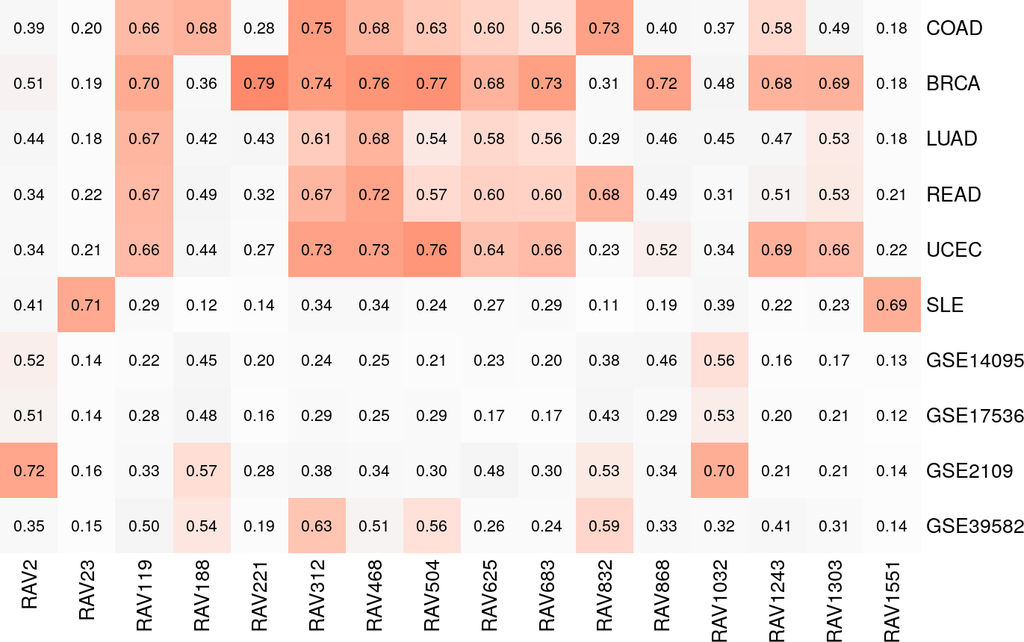

Based on this multi-datasets validation table,  
- RAV23 and RAV1551 are SLE-specific  
- RAV188 seems to be COAD-specific, different from RAV832 which is associated with both COAD and READ

## 3.2 MeSH terms and associated studies

### 3.2.1 SLE-associated

#### 3.2.1.1 RAV23

```r
ind <- 23
findStudiesInCluster(RAVmodel, ind, studyTitle = TRUE)
```

```
##      studyName
## 16   DRP001953
## 524  ERP114104
## 1749 SRP051848
## 2024 SRP059039
## 3329 SRP089814
## 4244 SRP110609
## 4533 SRP118733
## 4977 SRP132018
## 5135 SRP136057
## 5140 SRP136108
## 5452 SRP150419
## 5462 SRP150595
##                                                                                                                              title
## 16                         Interactive Transcriptome Analysis of Malaria Patients and Infecting Plasmodium falciparum in Indonesia
## 524                                                                   Altered Gene Expression in Antipsychotic Induced Weight Gain
## 1749                                    Gene Networks Specific for Innate Immunity Define Post-traumatic Stress Disorder [RNA-Seq]
## 2024                 Elucidating the etiology and molecular pathogenicity of infectious diarrhea by high throughput RNA sequencing
## 3329 Differentially Expressed Gene Transcripts Using RNA Sequencing from the Blood of Immunosuppressed Kidney Allograft Recipients
## 4244                 RNA-sequencing analysis of response to P.falciparum infection in Fulani and Mossi ethnic groups, Burkina Faso
## 4533                                                      Transcriptomic analysis of Multiple Myeloma bone marrow microenvironment
## 4977                                                                In-vitro stimulation of healthy donor blood with IL-3 cytokine
## 5135                           Whole Blood Transcriptome Profiling in Juvenile Idiopathic Arthritis and Inflammatory Bowel Disease
## 5140                                               RNA-seq of nine primary human cell types exposed in vitro to methylprednisolone
## 5452                                                                              Haemopedia: Human Haematopoietic Gene Expression
## 5462                                                                                 Homo sapiens Transcriptome or Gene expression
```

```r
subsetEnrichedPathways(RAVmodel, ind) %>% as.data.frame
```

```
##                                                                      RAV23
## Up_1                                                         KEGG_RIBOSOME
## Up_2  REACTOME_SRP_DEPENDENT_COTRANSLATIONAL_PROTEIN_TARGETING_TO_MEMBRANE
## Up_3                            REACTOME_EUKARYOTIC_TRANSLATION_ELONGATION
## Up_4                                  REACTOME_SELENOAMINO_ACID_METABOLISM
## Up_5                                              REACTOME_RRNA_PROCESSING
## Up_6                                                  REACTOME_TRANSLATION
## Up_7                                                     MANALO_HYPOXIA_DN
## Up_8                                       CAIRO_HEPATOBLASTOMA_CLASSES_UP
## Up_9                                              PUJANA_BRCA2_PCC_NETWORK
## Up_10                                        WONG_EMBRYONIC_STEM_CELL_CORE
```

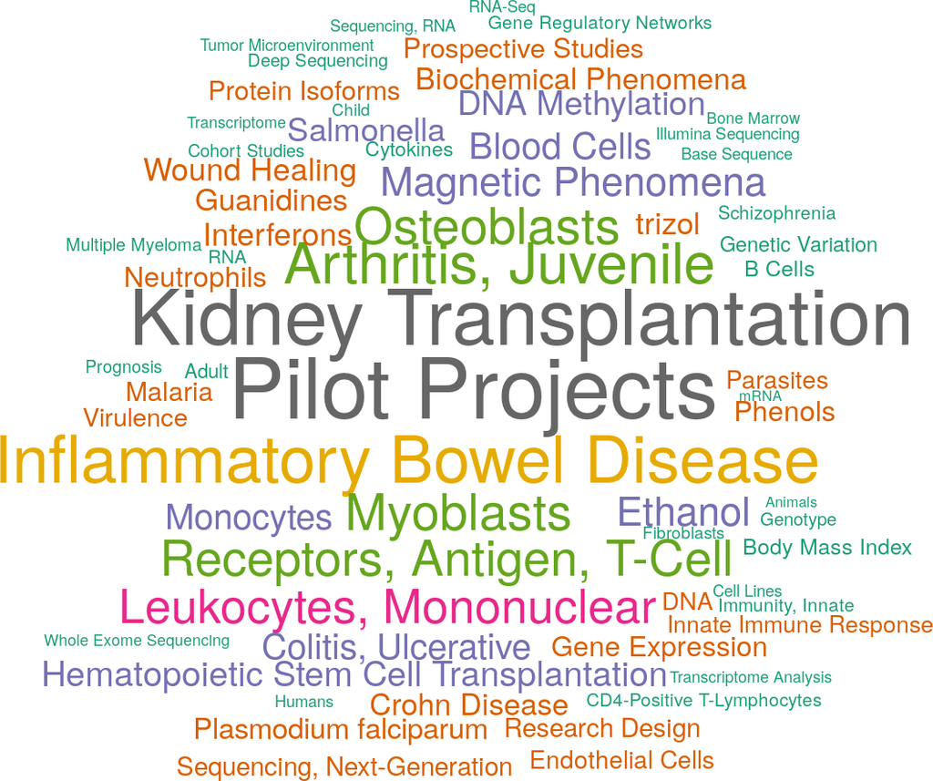

```r
drawWordcloud(RAVmodel, ind)
```

#### 3.2.1.2 RAV1551

```r
ind <- 1551
findStudiesInCluster(RAVmodel, ind, studyTitle = TRUE)
```

```
##      studyName
## 1740 SRP051688
## 1904 SRP056840
## 2209 SRP062966
## 2699 SRP071965
## 4031 SRP105369
## 4914 SRP131037
## 5462 SRP150595
## 5481 SRP150872
##                                                                                                                                                                    title
## 1740                                                      A Cell-based Systems Biology Assessment of Human Blood to Monitor Immune Responses After Influenza Vaccination
## 1904                                                                                      Renal systems biology of patients with systemic inflammatory response syndrome
## 2209                                                                                                                                                   SLE lupus RNA-seq
## 2699                                                                                     A blood RNA signature for tuberculosis disease risk: a prospective cohort study
## 4031 Transcriptome analysis of G protein-coupled receptors in distinct genetic subgroups of acute myeloid leukemia: identification of potential disease-specific targets
## 4914              Using Next-Generation Sequencing Transcriptomics to Determine Markers of Post-traumatic Symptoms  - preliminary findings from a post-deployment cohort
## 5462                                                                                                                       Homo sapiens Transcriptome or Gene expression
## 5481                                                                                          Discovering in vivo cytokine eQTL interactions from a lupus clinical trial
```

```r
subsetEnrichedPathways(RAVmodel, ind) %>% as.data.frame
```

```
##                                                     RAV1551
## Up_1                      REACTOME_NEUTROPHIL_DEGRANULATION
## Up_2                 THEILGAARD_NEUTROPHIL_AT_SKIN_WOUND_DN
## Up_3  ALTEMEIER_RESPONSE_TO_LPS_WITH_MECHANICAL_VENTILATION
## Up_4                       VERHAAK_AML_WITH_NPM1_MUTATED_UP
## Up_5                       VERHAAK_GLIOBLASTOMA_MESENCHYMAL
## Up_6                       HAHTOLA_MYCOSIS_FUNGOIDES_CD4_UP
## Up_7                      BROWN_MYELOID_CELL_DEVELOPMENT_UP
## Up_8             TAKEDA_TARGETS_OF_NUP98_HOXA9_FUSION_8D_DN
## Up_9                   LENAOUR_DENDRITIC_CELL_MATURATION_DN
## Up_10      SMIRNOV_CIRCULATING_ENDOTHELIOCYTES_IN_CANCER_UP
```

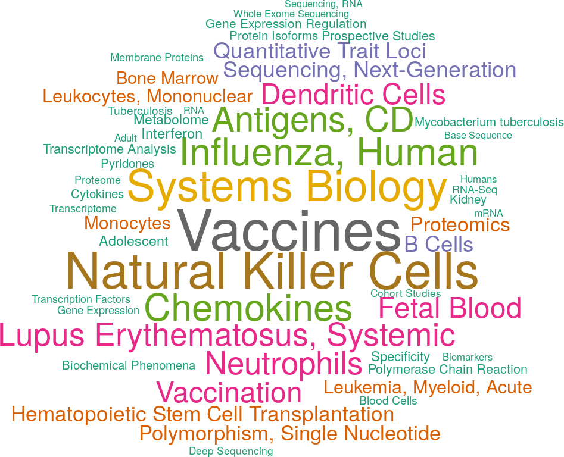

```r
drawWordcloud(RAVmodel, ind)
```

### 3.2.2 COAD-specific

```r
ind <- 188
findStudiesInCluster(RAVmodel, ind, studyTitle = TRUE)
```

```
##      studyName
## 220  ERP013206
## 351  ERP023272
## 357  ERP023550
## 1074 SRP029880
## 3037 SRP077046
## 5411 SRP149847
##                                                                                                                                                                                                          title
## 220                                                                                                                                   Whole transcriptome profiling of Esophageal adenocarcinoma and Barrett's
## 351                                         RNA-seq of formalin-fixed, paraffin-embedded uninvolved terminal ileal tissue obtained from ileo-colic resection surgeries of Crohn’s disease and control patients
## 357                                                                                                         RNA-seq of human intestinal organoids colonized with E. coli and other immature intestinal tissues
## 1074                                                                                                                                           Gene expression profiling study by RNA-seq in colorectal cancer
## 3037 A functional genomics predictive network model identifies regulators of inflammatory bowel disease: Mount Sinai Hospital (MSH) Population Specimen Collection and Profiling of Inflammatory Bowel Disease
## 5411                                                                               Differences in tissue immune cell populations following hematopoietic stem cell transplantation in Crohn's disease patients
```

```r
subsetEnrichedPathways(RAVmodel, ind, both=TRUE) %>% as.data.frame
```

```
##                                                                                                                            RAV188
## Up_1                                                                                     SCHUETZ_BREAST_CANCER_DUCTAL_INVASIVE_UP
## Up_2                                                                                   VECCHI_GASTRIC_CANCER_ADVANCED_VS_EARLY_UP
## Up_3                                                                                                     LIM_MAMMARY_STEM_CELL_UP
## Up_4                                                                               ANASTASSIOU_MULTICANCER_INVASIVENESS_SIGNATURE
## Up_5                                                                                                         BOQUEST_STEM_CELL_UP
## Up_6                                                                              CHARAFE_BREAST_CANCER_LUMINAL_VS_MESENCHYMAL_DN
## Up_7                                                                                           LINDGREN_BLADDER_CANCER_CLUSTER_2B
## Up_8                                                                                     PICCALUGA_ANGIOIMMUNOBLASTIC_LYMPHOMA_UP
## Up_9                                                                      TURASHVILI_BREAST_LOBULAR_CARCINOMA_VS_DUCTAL_NORMAL_UP
## Up_10                                                                                           SMID_BREAST_CANCER_NORMAL_LIKE_UP
## Down_1                                                                                          WAMUNYOKOLI_OVARIAN_CANCER_LMP_UP
## Down_2                                                                                                HOLLERN_EMT_BREAST_TUMOR_DN
## Down_3                                                                            CHARAFE_BREAST_CANCER_LUMINAL_VS_MESENCHYMAL_UP
## Down_4                                                                                                   LIM_MAMMARY_STEM_CELL_DN
## Down_5                                                                                 VECCHI_GASTRIC_CANCER_ADVANCED_VS_EARLY_DN
## Down_6                                                                                            COLDREN_GEFITINIB_RESISTANCE_DN
## Down_7                                                                                             WOO_LIVER_CANCER_RECURRENCE_DN
## Down_8  REACTOME_RESPIRATORY_ELECTRON_TRANSPORT_ATP_SYNTHESIS_BY_CHEMIOSMOTIC_COUPLING_AND_HEAT_PRODUCTION_BY_UNCOUPLING_PROTEINS
## Down_9                                                                                    REACTOME_RESPIRATORY_ELECTRON_TRANSPORT
## Down_10                                                                                  WAMUNYOKOLI_OVARIAN_CANCER_GRADES_1_2_UP
```

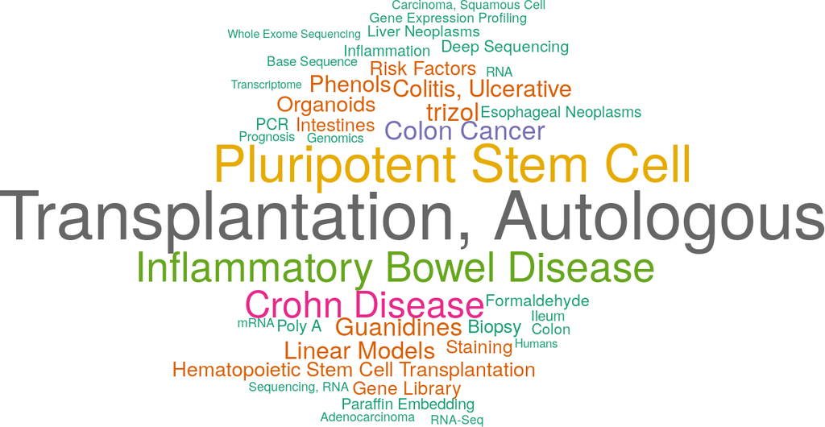

```r
drawWordcloud(RAVmodel, ind)
```

# 4 Manuscript Figures

## 4.1 Fig 2. Connect new data with the existing databases

A RAVmodel provides a rich resource for understanding new or user-supplied datasets in the context of all other RAVmodel datasets. A) Validation of multiple datasets. Each dataset was subjected to PCA and correlated to all possible RAVs using Pearson correlation. RAVs with correlation above 0.7 in at least one dataset were included. RAV221 and RAV868 seem to be associated with breast cancer while RAV832 is associated with colon and rectal cancer. B) Validation of a single dataset, TCGA-BRCA. Top 5 validated RAVs (score, bottom panel) and their average silhouette width (avg.sw, top panel) are shown. C) MeSH terms associated with RAV221 can aid in interpreting the biological context of the RAV when plotted as a word cloud. D) Studies contributing to RAV221. Study accession number (studyName column) and the title of a study (title column) are shown here. E) Top 10 enriched pathways in RAV221.

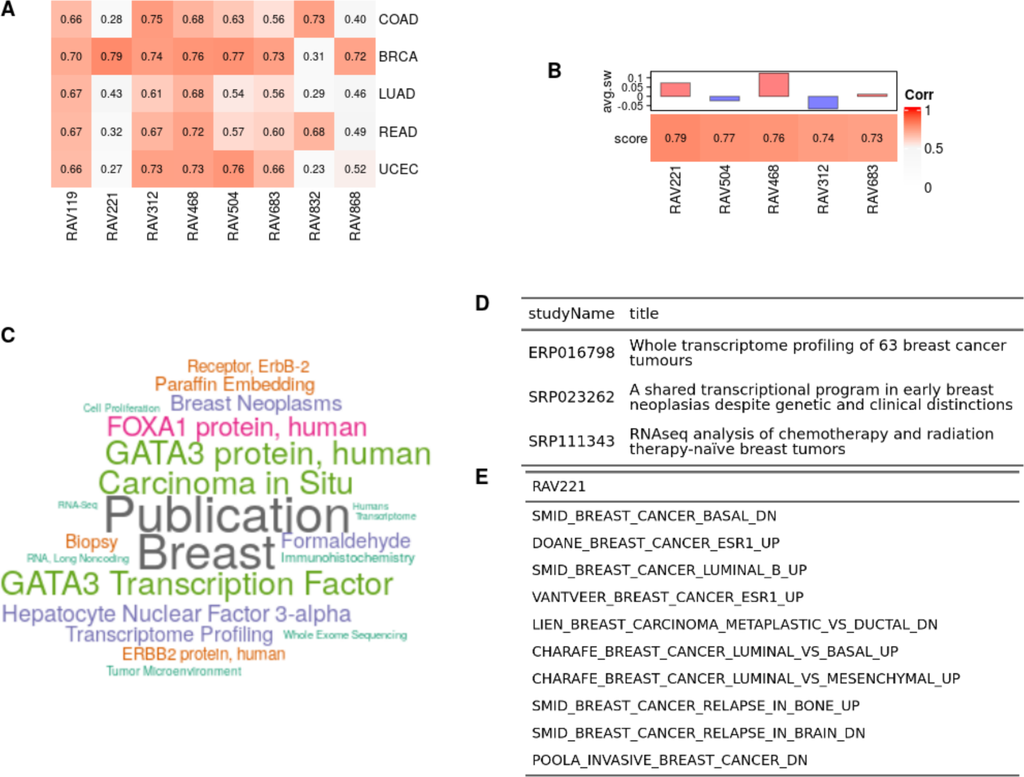

## 4.2 Sup.Fig 4. Colon and rectal cancer associated RAV

Based on Figure 2A, RAV832 seems to be associated with TCGA-COAD and TCGA-READ. Top validation results of A) TCGA-COAD and B) TCGA-READ include RAV832 with the negative average silhouette width. C) MeSH terms associated with RAV832. D) Studies contributing to RAV832. E) MSigDB C2 gene sets enriched in RAV832.

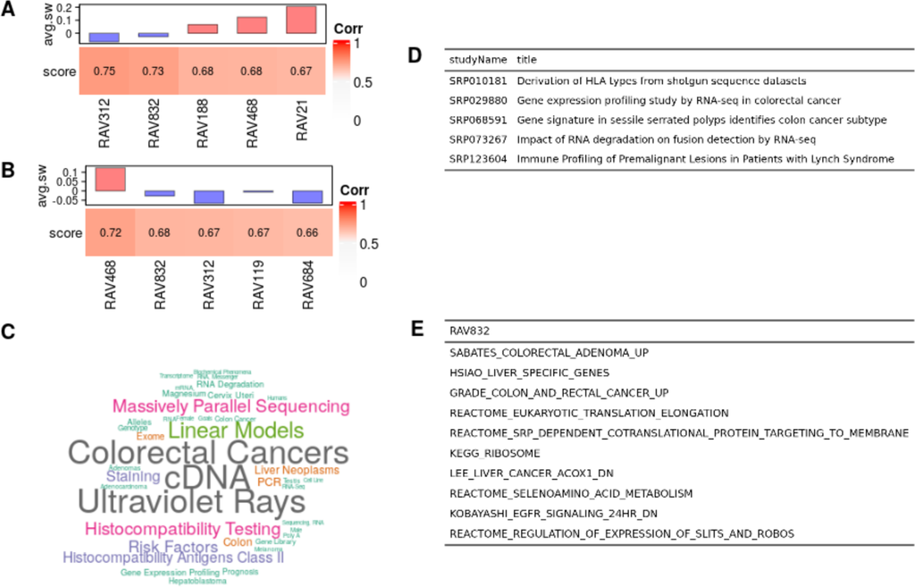